# Project: Problem Statement - Personal Loan Campaign Modelling

## Thera Bank Personal Loan Campaign

## Data Description:

The dataset contains data on 5000 customers. The data include customer demographic information (age, income, etc.), the customer's relationship with the bank (mortgage, securities account, etc.), and the customer response to the last personal loan campaign (Personal Loan). Among these 5000 customers, only 480 (= 9.6%) accepted the personal loan that was offered to them in the earlier campaign.

## Domain:

Banking

## Context:

This case is about a bank (Thera Bank) whose management wants to explore ways of converting its liability customers to personal loan customers (while retaining them as depositors). A campaign that the bank ran last year for liability customers showed a healthy conversion rate of over 9% success. This has encouraged the retail marketing department to devise campaigns with better target marketing to increase the success ratio with a minimal budget.

## Attribute Information:

- ID: Customer ID
- Age: Customer's age in completed years
- Experience: #years of professional experience
- Income: Annual income of the customer
- ZIP Code: Home Address ZIP
- Family: Family size of the customer
- CCAvg: Avg. spending on credit cards per month
- Education: Education Level. 1: Undergrad; 2: Graduate; 3: Advanced/Professional
- Mortgage: Value of house mortgage if any.
- Personal Loan: Did this customer accept the personal loan offered in the last campaign?
- Securities Account: Does the customer have a securities account with the bank?
- CD Account: Does the customer have a certificate of deposit (CD) account with the bank?
- Online: Does the customer use internet banking facilities?
- Credit card: Does the customer use a credit card issued by the bank?

## Learning Outcomes:

Exploratory Data Analysis Preparing the data to train a model Training and making predictions using a classification model Model evaluation

## Objective:

The classification goal is to predict the likelihood of a liability customer buying personal loans.

## Steps and tasks:

1. Import the datasets and libraries, check datatype, statistical summary, shape, null values or incorrect imputation. (5 marks)
2. EDA: Study the data distribution in each attribute and target variable, share your findings (20 marks)
- Number of unique in each column?
- Number of people with zero mortgage?
- Number of people with zero credit card spending per month?
- Value counts of all categorical columns.
- Univariate and Bivariate
- Get data model ready
1. Split the data into training and test set in the ratio of 70:30 respectively (5 marks)
2. Use the Logistic Regression model to predict whether the customer will take a personal loan or not. Print all the metrics related to evaluating the model performance (accuracy, recall, precision, f1score, and roc_auc_score). Draw a heatmap to display confusion matrix (15 marks)
3. Find out coefficients of all the attributes and show the output in a data frame with column names? For test data show all the rows where the predicted class is not equal to the observed class. (10 marks)
4. Give conclusion related to the Business understanding of your model? (5 marks)

## 1. Import the datasets and libraries, check datatype, statistical summary, shape, null values or incorrect imputation. (5 marks)

```python
import numpy as np
import pandas as pd
import matplotlib.pyplot as plt
import seaborn as sns
```

```python
data = pd.read_csv("Bank_Personal_Loan_Modelling.csv")
```

```python
print(data.dtypes)
```

```
ID                      int64
Age                     int64
Experience              int64
Income                  int64
ZIP Code                int64
Family                  int64
CCAvg                 float64
Education               int64
Mortgage                int64
Personal Loan           int64
Securities Account      int64
CD Account              int64
Online                  int64
CreditCard              int64
dtype: object
```

```python
data.head()
```

|  | ID | Age | Experience | Income | ZIP Code | Family | CCAvg | Education | Mortgage | Personal Loan | Securities Account | CD Account | Online | CreditCard |
| --- | --- | --- | --- | --- | --- | --- | --- | --- | --- | --- | --- | --- | --- | --- |
| 0 | 1 | 25 | 1 | 49 | 91107 | 4 | 1.6 | 1 | 0 | 0 | 1 | 0 | 0 | 0 |
| 1 | 2 | 45 | 19 | 34 | 90089 | 3 | 1.5 | 1 | 0 | 0 | 1 | 0 | 0 | 0 |
| 2 | 3 | 39 | 15 | 11 | 94720 | 1 | 1.0 | 1 | 0 | 0 | 0 | 0 | 0 | 0 |
| 3 | 4 | 35 | 9 | 100 | 94112 | 1 | 2.7 | 2 | 0 | 0 | 0 | 0 | 0 | 0 |
| 4 | 5 | 35 | 8 | 45 | 91330 | 4 | 1.0 | 2 | 0 | 0 | 0 | 0 | 0 | 1 |

```python
data[['Age', 'Experience', 'Income', 'Family', 'CCAvg', 'Mortgage']].describe()
```

|  | Age | Experience | Income | Family | CCAvg | Mortgage |
| --- | --- | --- | --- | --- | --- | --- |
| count | 5000.000000 | 5000.000000 | 5000.000000 | 5000.000000 | 5000.000000 | 5000.000000 |
| mean | 45.338400 | 20.104600 | 73.774200 | 2.396400 | 1.937938 | 56.498800 |
| std | 11.463166 | 11.467954 | 46.033729 | 1.147663 | 1.747659 | 101.713802 |
| min | 23.000000 | -3.000000 | 8.000000 | 1.000000 | 0.000000 | 0.000000 |
| 25% | 35.000000 | 10.000000 | 39.000000 | 1.000000 | 0.700000 | 0.000000 |
| 50% | 45.000000 | 20.000000 | 64.000000 | 2.000000 | 1.500000 | 0.000000 |
| 75% | 55.000000 | 30.000000 | 98.000000 | 3.000000 | 2.500000 | 101.000000 |
| max | 67.000000 | 43.000000 | 224.000000 | 4.000000 | 10.000000 | 635.000000 |

```python
print(data.shape)
```

```
(5000, 14)
```

```python
data.isna().any()
```

```
ID                    False
Age                   False
Experience            False
Income                False
ZIP Code              False
Family                False
CCAvg                 False
Education             False
Mortgage              False
Personal Loan         False
Securities Account    False
CD Account            False
Online                False
CreditCard            False
dtype: bool
```

```python
print(data[data['ZIP Code'] <= 0].shape[0])
```

```
0
```

```python
print(data[(data['Experience'] < 0)].shape[0])
```

```
52
```

```python
print(data[(data['Experience'] < 0)][['Age']].value_counts())
```

```
Age
25     18
24     17
23     12
29      3
28      1
26      1
dtype: int64
```

```python
print(data[(data['Experience'] < 0)][['Experience']].value_counts())
```

```
Experience
-1            33
-2            15
-3             4
dtype: int64
```

```python
print(data[(data['Age'] < 30)].shape[0])
```

```
488
```

```python
print(data[(data['Experience'] > data['Age'] - 18)])
```

```
Empty DataFrame
Columns: [ID, Age, Experience, Income, ZIP Code, Family, CCAvg, Education, Mortgage, Personal Loan, Securities Account, CD Account, Online, CreditCard]
Index: []
```

```python
print(data[["Mortgage", "Personal Loan", "Securities Account", "CD Account", "Online", "CreditCard"]].min())
```

```
Mortgage              0
Personal Loan         0
Securities Account    0
CD Account            0
Online                0
CreditCard            0
dtype: int64
```

```python
print(data[["Mortgage", "Personal Loan", "Securities Account", "CD Account", "Online", "CreditCard"]].max())
```

```
Mortgage              635
Personal Loan           1
Securities Account      1
CD Account              1
Online                  1
CreditCard              1
dtype: int64
```

```python
print(data[['Education']].describe())
```

```
         Education
count  5000.000000
mean      1.881000
std       0.839869
min       1.000000
25%       1.000000
50%       2.000000
75%       3.000000
max       3.000000
```

## Conclusions:

1. There are 5000 rows and 14 columns in the data set
2. 13 columns have type int64 and 1 column has type float64
3. There are no null values in the data set
4. There are incorrect imputations in Experience column: some values are negative ranging from -1 to -3. Only customers in their 20s have negative Experience values. Taking into account their young age and small absolute values of the negative experience values, we can assume that these customer either don't have work experience or their work experience should be a positive number with the same absolute value. There are 52 such rows, which is ~1% of total number of customers and ~11% of customers of age 29 and younger.

## 2. EDA: Study the data distribution in each attribute and target variable, share your findings (20 marks)

- Number of unique in each column?
- Number of people with zero mortgage?
- Number of people with zero credit card spending per month?
- Value counts of all categorical columns.
- Univariate and Bivariate
- Get data model ready

```python
print(data.nunique())
```

```
ID                    5000
Age                     45
Experience              47
Income                 162
ZIP Code               467
Family                   4
CCAvg                  108
Education                3
Mortgage               347
Personal Loan            2
Securities Account       2
CD Account               2
Online                   2
CreditCard               2
dtype: int64
```

```python
zero_mortage_df = data[data['Mortgage'] == 0]
no_zero_mortage = zero_mortage_df.shape[0]
print ("There are {} people with 0 mortage".format(no_zero_mortage))
```

```
There are 3462 people with 0 mortage
```

```python
zero_ccavg_df = data[data['CCAvg'] == 0]
no_zero_ccavg = zero_ccavg_df.shape[0]
print ("There are {} people with 0 average credit card spending".format(no_zero_ccavg))
```

```
There are 106 people with 0 average credit card spending
```

```python
categorical_columns = ["Personal Loan", "Securities Account", "CD Account", \
                       "Online", "CreditCard", "ZIP Code", "Education"]
for col in categorical_columns:
    print(data[col].value_counts())
```

```
0    4520
1     480
Name: Personal Loan, dtype: int64
0    4478
1     522
Name: Securities Account, dtype: int64
0    4698
1     302
Name: CD Account, dtype: int64
1    2984
0    2016
Name: Online, dtype: int64
0    3530
1    1470
Name: CreditCard, dtype: int64
```

[output cut: 16 more lines]

Columns "Personal Loan", "Securities Account", "CD Account", "Online", "CreditCard" have 2 values: 0 or 1. We don't need One Hot encoding for these columns. Column "Education" has 3 values: 1, 2, 3. We need 3 One hot encode columns for this column, one of which will be dropped before regression model calculation. Column "ZIP Code" has 467. Number of customers living in a specific ZIp Code ranges from 1 to 169. We would need to create 467 one hot encode columns for regression model which can lead to model overfitting. Before continue we want for group zip codes to larger areas based on their first to digits. For example zip codes 94598, 94087, 94305 will be in 94xxx area, while 90095 and 90068 will be in 90xxx area.

```python
clean_data = data
clean_data['ZIP Code']=clean_data['ZIP Code'].apply(lambda x: str(x)[0:2]+'xxx')
```

```python
print(clean_data['ZIP Code'].value_counts())
print("Now we have only {} unique values in column Zip Code".format(clean_data['ZIP Code'].nunique()))
```

```
94xxx    1472
92xxx     988
95xxx     815
90xxx     703
91xxx     565
93xxx     417
96xxx      40
Name: ZIP Code, dtype: int64
Now we have only 7 unique values in column Zip Code
```

Now we have only 7 unique values in column Zip Code. We need 7 One hot encode columns for this column, one of which will be dropped before regression model calculation.

### Univariate analysis

```python
numerical_columns = ["Age", "Experience", "Income", "Family", "CCAvg", "Mortgage"]
clean_data[numerical_columns].describe().T
```

|  | count | mean | std | min | 25% | 50% | 75% | max |
| --- | --- | --- | --- | --- | --- | --- | --- | --- |
| Age | 5000.0 | 45.338400 | 11.463166 | 23.0 | 35.0 | 45.0 | 55.0 | 67.0 |
| Experience | 5000.0 | 20.104600 | 11.467954 | -3.0 | 10.0 | 20.0 | 30.0 | 43.0 |
| Income | 5000.0 | 73.774200 | 46.033729 | 8.0 | 39.0 | 64.0 | 98.0 | 224.0 |
| Family | 5000.0 | 2.396400 | 1.147663 | 1.0 | 1.0 | 2.0 | 3.0 | 4.0 |
| CCAvg | 5000.0 | 1.937938 | 1.747659 | 0.0 | 0.7 | 1.5 | 2.5 | 10.0 |
| Mortgage | 5000.0 | 56.498800 | 101.713802 | 0.0 | 0.0 | 0.0 | 101.0 | 635.0 |

```python
clean_data[numerical_columns].skew()
```

```
Age          -0.029341
Experience   -0.026325
Income        0.841339
Family        0.155221
CCAvg         1.598443
Mortgage      2.104002
dtype: float64
```

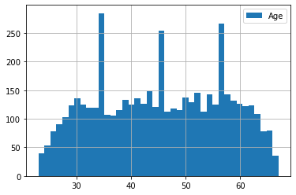

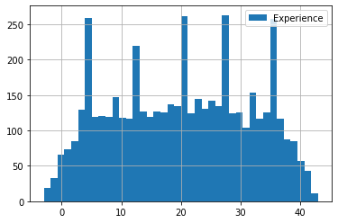

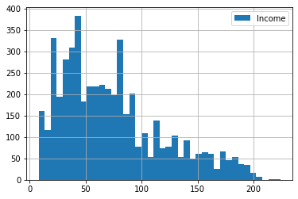

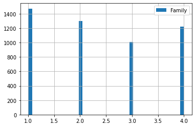

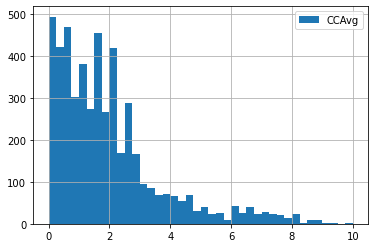

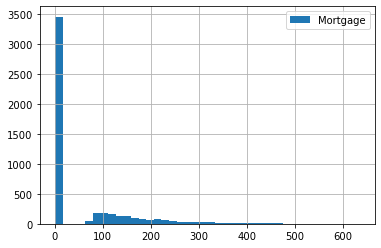

```python
for col in numerical_columns:
  clean_data[col].hist(bins=40, legend=True)
  plt.show()
```

### Bivariate analisys

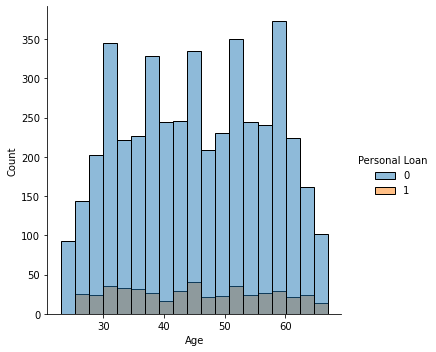

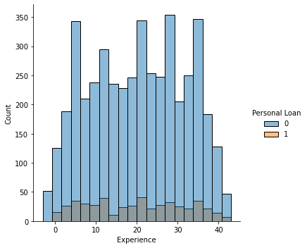

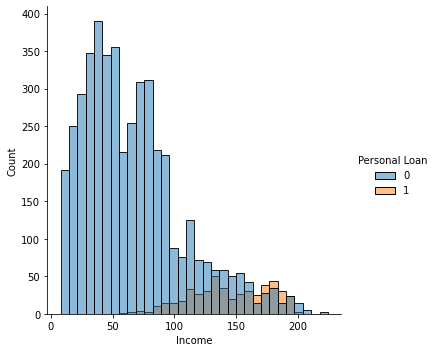

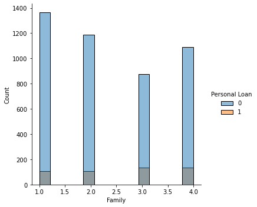

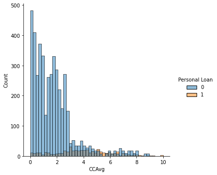

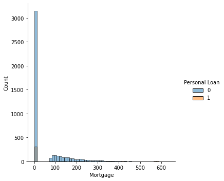

```python
output = 'Personal Loan'
for col in numerical_columns:
  sns.displot(data=clean_data, x=col, hue=output)
  plt.show()
```

Customers with higher income tend to accept personal loan offers more frequently

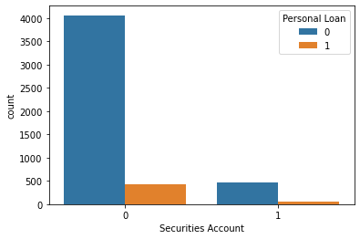

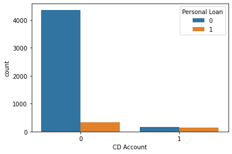

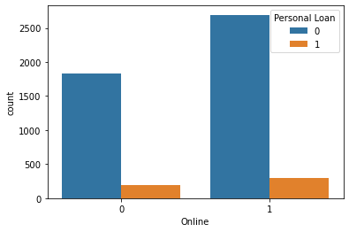

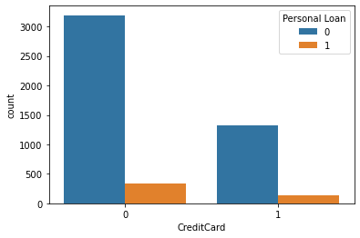

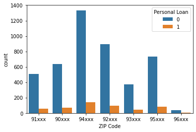

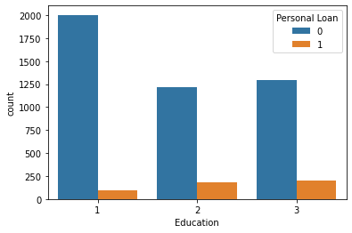

```python
categorical_columns = ["Securities Account", "CD Account", \
                       "Online", "CreditCard", "ZIP Code", "Education"]
for col in categorical_columns:
    sns.countplot(data=clean_data, hue=output, x=col)
    plt.show()
```

Customers with higher education level accept personal loan offer more frequently

Customers having CD accounts accept personal loan offer more frequently

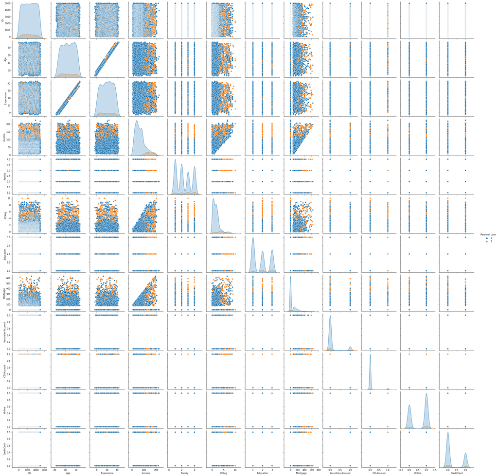

```python
sns.pairplot(clean_data, hue=output)
```

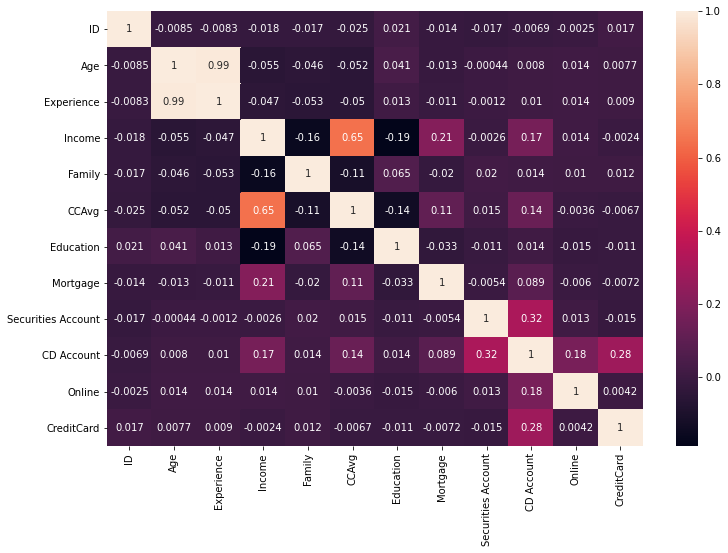

```python
corr = clean_data.drop(output, axis=1).corr()
plt.figure(figsize=(12,8))
sns.heatmap(corr, annot=True)
plt.show()
```

There is a very high correltion between Age and Experience. Correlation coefficient is 0.99. We can drop one of this column when calculating regression coefficients. If we drop column Experience, it will also solve the issue with negative Experience values

### Data preparation

```python
clean_data = clean_data.drop(columns=['Experience', 'ID'])
clean_data.head()
```

|  | Age | Income | ZIP Code | Family | CCAvg | Education | Mortgage | Personal Loan | Securities Account | CD Account | Online | CreditCard |
| --- | --- | --- | --- | --- | --- | --- | --- | --- | --- | --- | --- | --- |
| 0 | 25 | 49 | 91xxx | 4 | 1.6 | 1 | 0 | 0 | 1 | 0 | 0 | 0 |
| 1 | 45 | 34 | 90xxx | 3 | 1.5 | 1 | 0 | 0 | 1 | 0 | 0 | 0 |
| 2 | 39 | 11 | 94xxx | 1 | 1.0 | 1 | 0 | 0 | 0 | 0 | 0 | 0 |
| 3 | 35 | 100 | 94xxx | 1 | 2.7 | 2 | 0 | 0 | 0 | 0 | 0 | 0 |
| 4 | 35 | 45 | 91xxx | 4 | 1.0 | 2 | 0 | 0 | 0 | 0 | 0 | 1 |

We need to normalize all numerical columns to make model coefficients unitless

```python
numerical_columns = ["Age", "Income", "Family", "CCAvg", "Mortgage"]
```

```python
from sklearn.preprocessing import StandardScaler
```

```python
for col in numerical_columns:
  clean_data[col] = StandardScaler().fit_transform(clean_data[[col]])
```

```python
clean_data[numerical_columns].describe()
```

|  | Age | Income | Family | CCAvg | Mortgage |
| --- | --- | --- | --- | --- | --- |
| count | 5.000000e+03 | 5.000000e+03 | 5.000000e+03 | 5.000000e+03 | 5.000000e+03 |
| mean | 2.478018e-17 | 1.939449e-16 | 7.850609e-16 | -2.078338e-17 | 2.810197e-16 |
| std | 1.000100e+00 | 1.000100e+00 | 1.000100e+00 | 1.000100e+00 | 1.000100e+00 |
| min | -1.948906e+00 | -1.428969e+00 | -1.216855e+00 | -1.108987e+00 | -5.555239e-01 |
| 25% | -9.019702e-01 | -7.554825e-01 | -1.216855e+00 | -7.084116e-01 | -5.555239e-01 |
| 50% | -2.952359e-02 | -2.123482e-01 | -3.454321e-01 | -2.506106e-01 | -5.555239e-01 |
| 75% | 8.429230e-01 | 5.263146e-01 | 5.259909e-01 | 3.216407e-01 | 4.375576e-01 |
| max | 1.889859e+00 | 3.263712e+00 | 1.397414e+00 | 4.613525e+00 | 5.688108e+00 |

```python
X = clean_data.drop(output, axis=1)
y = clean_data[[output]]

print(X.head())
print(y.head())
```

```
        Age    Income ZIP Code    Family     CCAvg  Education  Mortgage  \
0 -1.774417 -0.538229    91xxx  1.397414 -0.193385          1 -0.555524
1 -0.029524 -0.864109    90xxx  0.525991 -0.250611          1 -0.555524
2 -0.552992 -1.363793    94xxx -1.216855 -0.536736          1 -0.555524
3 -0.901970  0.569765    94xxx -1.216855  0.436091          2 -0.555524
4 -0.901970 -0.625130    91xxx  1.397414 -0.536736          2 -0.555524

   Securities Account  CD Account  Online  CreditCard
0                   1           0       0           0
1                   1           0       0           0
2                   0           0       0           0
3                   0           0       0           0
4                   0           0       0           1
   Personal Loan
0              0
1              0
2              0
3              0
4              0
```

```python
print(X.shape)
print(y.shape)
```

```
(5000, 11)
(5000, 1)
```

```python
X = pd.get_dummies(X, columns=['Education', 'ZIP Code'])
```

```python
X.head()
```

|  | Age | Income | Family | CCAvg | Mortgage | Securities Account | CD Account | Online | CreditCard | Education_1 | Education_2 | Education_3 | ZIP Code_90xxx | ZIP Code_91xxx | ZIP Code_92xxx | ZIP Code_93xxx | ZIP Code_94xxx | ZIP Code_95xxx | ZIP Code_96xxx |
| --- | --- | --- | --- | --- | --- | --- | --- | --- | --- | --- | --- | --- | --- | --- | --- | --- | --- | --- | --- |
| 0 | -1.774417 | -0.538229 | 1.397414 | -0.193385 | -0.555524 | 1 | 0 | 0 | 0 | 1 | 0 | 0 | 0 | 1 | 0 | 0 | 0 | 0 | 0 |
| 1 | -0.029524 | -0.864109 | 0.525991 | -0.250611 | -0.555524 | 1 | 0 | 0 | 0 | 1 | 0 | 0 | 1 | 0 | 0 | 0 | 0 | 0 | 0 |
| 2 | -0.552992 | -1.363793 | -1.216855 | -0.536736 | -0.555524 | 0 | 0 | 0 | 0 | 1 | 0 | 0 | 0 | 0 | 0 | 0 | 1 | 0 | 0 |
| 3 | -0.901970 | 0.569765 | -1.216855 | 0.436091 | -0.555524 | 0 | 0 | 0 | 0 | 0 | 1 | 0 | 0 | 0 | 0 | 0 | 1 | 0 | 0 |
| 4 | -0.901970 | -0.625130 | 1.397414 | -0.536736 | -0.555524 | 0 | 0 | 0 | 1 | 0 | 1 | 0 | 0 | 1 | 0 | 0 | 0 | 0 | 0 |

```python
X = X.drop(["Education_1", "ZIP Code_94xxx"], axis=1)
```

```python
X.head()
```

|  | Age | Income | Family | CCAvg | Mortgage | Securities Account | CD Account | Online | CreditCard | Education_2 | Education_3 | ZIP Code_90xxx | ZIP Code_91xxx | ZIP Code_92xxx | ZIP Code_93xxx | ZIP Code_95xxx | ZIP Code_96xxx |
| --- | --- | --- | --- | --- | --- | --- | --- | --- | --- | --- | --- | --- | --- | --- | --- | --- | --- |
| 0 | -1.774417 | -0.538229 | 1.397414 | -0.193385 | -0.555524 | 1 | 0 | 0 | 0 | 0 | 0 | 0 | 1 | 0 | 0 | 0 | 0 |
| 1 | -0.029524 | -0.864109 | 0.525991 | -0.250611 | -0.555524 | 1 | 0 | 0 | 0 | 0 | 0 | 1 | 0 | 0 | 0 | 0 | 0 |
| 2 | -0.552992 | -1.363793 | -1.216855 | -0.536736 | -0.555524 | 0 | 0 | 0 | 0 | 0 | 0 | 0 | 0 | 0 | 0 | 0 | 0 |
| 3 | -0.901970 | 0.569765 | -1.216855 | 0.436091 | -0.555524 | 0 | 0 | 0 | 0 | 1 | 0 | 0 | 0 | 0 | 0 | 0 | 0 |
| 4 | -0.901970 | -0.625130 | 1.397414 | -0.536736 | -0.555524 | 0 | 0 | 0 | 1 | 1 | 0 | 0 | 1 | 0 | 0 | 0 | 0 |

```python
print(X.shape)
print(y.shape)
```

```
(5000, 17)
(5000, 1)
```

## 3. Split the data into training and test set in the ratio of 70:30 respectively (5 marks)

```python
from sklearn.model_selection import train_test_split
```

```python
x_train, x_test, y_train, y_test = train_test_split(X, y, test_size=0.30, random_state=1)
```

```python
print(len(x_train), len(y_train))
print(len(x_test), len(y_test))
```

```
3500 3500
1500 1500
```

```python
x_train.describe()
```

|  | Age | Income | Family | CCAvg | Mortgage | Securities Account | CD Account | Online | CreditCard | Education_2 | Education_3 | ZIP Code_90xxx | ZIP Code_91xxx | ZIP Code_92xxx | ZIP Code_93xxx | ZIP Code_95xxx | ZIP Code_96xxx |
| --- | --- | --- | --- | --- | --- | --- | --- | --- | --- | --- | --- | --- | --- | --- | --- | --- | --- |
| count | 3500.000000 | 3500.000000 | 3500.000000 | 3500.000000 | 3500.000000 | 3500.000000 | 3500.000000 | 3500.000000 | 3500.000000 | 3500.000000 | 3500.000000 | 3500.000000 | 3500.000000 | 3500.000000 | 3500.000000 | 3500.000000 | 3500.000000 |
| mean | 0.008465 | -0.002916 | -0.001096 | -0.002079 | -0.004365 | 0.104571 | 0.062571 | 0.591143 | 0.297429 | 0.282286 | 0.302000 | 0.139429 | 0.116000 | 0.192857 | 0.080286 | 0.162286 | 0.006857 |
| std | 1.003996 | 1.003023 | 0.998349 | 0.992688 | 0.988401 | 0.306044 | 0.242225 | 0.491693 | 0.457192 | 0.450176 | 0.459191 | 0.346443 | 0.320271 | 0.394598 | 0.271774 | 0.368765 | 0.082535 |
| min | -1.948906 | -1.428969 | -1.216855 | -1.108987 | -0.555524 | 0.000000 | 0.000000 | 0.000000 | 0.000000 | 0.000000 | 0.000000 | 0.000000 | 0.000000 | 0.000000 | 0.000000 | 0.000000 | 0.000000 |
| 25% | -0.901970 | -0.755483 | -1.216855 | -0.708412 | -0.555524 | 0.000000 | 0.000000 | 0.000000 | 0.000000 | 0.000000 | 0.000000 | 0.000000 | 0.000000 | 0.000000 | 0.000000 | 0.000000 | 0.000000 |
| 50% | -0.029524 | -0.234074 | -0.345432 | -0.250611 | -0.555524 | 0.000000 | 0.000000 | 1.000000 | 0.000000 | 0.000000 | 0.000000 | 0.000000 | 0.000000 | 0.000000 | 0.000000 | 0.000000 | 0.000000 |
| 75% | 0.842923 | 0.526315 | 0.525991 | 0.321641 | 0.430183 | 0.000000 | 0.000000 | 1.000000 | 1.000000 | 1.000000 | 1.000000 | 0.000000 | 0.000000 | 0.000000 | 0.000000 | 0.000000 | 0.000000 |
| max | 1.889859 | 3.263712 | 1.397414 | 4.613525 | 5.511123 | 1.000000 | 1.000000 | 1.000000 | 1.000000 | 1.000000 | 1.000000 | 1.000000 | 1.000000 | 1.000000 | 1.000000 | 1.000000 | 1.000000 |

```python
x_test.describe()
```

|  | Age | Income | Family | CCAvg | Mortgage | Securities Account | CD Account | Online | CreditCard | Education_2 | Education_3 | ZIP Code_90xxx | ZIP Code_91xxx | ZIP Code_92xxx | ZIP Code_93xxx | ZIP Code_95xxx | ZIP Code_96xxx |
| --- | --- | --- | --- | --- | --- | --- | --- | --- | --- | --- | --- | --- | --- | --- | --- | --- | --- |
| count | 1500.000000 | 1500.000000 | 1500.000000 | 1500.000000 | 1500.000000 | 1500.000000 | 1500.000000 | 1500.000000 | 1500.00000 | 1500.000000 | 1500.000000 | 1500.000000 | 1500.00000 | 1500.000000 | 1500.000000 | 1500.000000 | 1500.000000 |
| mean | -0.019752 | 0.006803 | 0.002556 | 0.004850 | 0.010185 | 0.104000 | 0.055333 | 0.610000 | 0.28600 | 0.276667 | 0.296000 | 0.143333 | 0.10600 | 0.208667 | 0.090667 | 0.164667 | 0.010667 |
| std | 0.991002 | 0.993547 | 1.004502 | 1.017503 | 1.027143 | 0.305362 | 0.228706 | 0.487913 | 0.45204 | 0.447499 | 0.456643 | 0.350529 | 0.30794 | 0.406491 | 0.287230 | 0.371003 | 0.102762 |
| min | -1.948906 | -1.428969 | -1.216855 | -1.108987 | -0.555524 | 0.000000 | 0.000000 | 0.000000 | 0.00000 | 0.000000 | 0.000000 | 0.000000 | 0.00000 | 0.000000 | 0.000000 | 0.000000 | 0.000000 |
| 25% | -0.901970 | -0.755483 | -1.216855 | -0.725579 | -0.555524 | 0.000000 | 0.000000 | 0.000000 | 0.00000 | 0.000000 | 0.000000 | 0.000000 | 0.00000 | 0.000000 | 0.000000 | 0.000000 | 0.000000 |
| 50% | -0.029524 | -0.212348 | -0.345432 | -0.250611 | -0.555524 | 0.000000 | 0.000000 | 1.000000 | 0.00000 | 0.000000 | 0.000000 | 0.000000 | 0.00000 | 0.000000 | 0.000000 | 0.000000 | 0.000000 |
| 75% | 0.842923 | 0.591491 | 0.525991 | 0.378866 | 0.447390 | 0.000000 | 0.000000 | 1.000000 | 1.00000 | 1.000000 | 1.000000 | 0.000000 | 0.00000 | 0.000000 | 0.000000 | 0.000000 | 0.000000 |
| max | 1.889859 | 2.785754 | 1.397414 | 4.613525 | 5.688108 | 1.000000 | 1.000000 | 1.000000 | 1.00000 | 1.000000 | 1.000000 | 1.000000 | 1.00000 | 1.000000 | 1.000000 | 1.000000 | 1.000000 |

```python
y_train.describe()
```

|  | Personal Loan |
| --- | --- |
| count | 3500.000000 |
| mean | 0.094571 |
| std | 0.292664 |
| min | 0.000000 |
| 25% | 0.000000 |
| 50% | 0.000000 |
| 75% | 0.000000 |
| max | 1.000000 |

```python
y_test.describe()
```

|  | Personal Loan |
| --- | --- |
| count | 1500.000000 |
| mean | 0.099333 |
| std | 0.299209 |
| min | 0.000000 |
| 25% | 0.000000 |
| 50% | 0.000000 |
| 75% | 0.000000 |
| max | 1.000000 |

Statistics of training and test sets are pretty close for all variables

## 4. Use the Logistic Regression model to predict whether the customer will take a personal loan or not. Print all the metrics related to evaluating the model performance (accuracy, recall, precision, f1score, and roc_auc_score). Draw a heatmap to display confusion matrix (15 marks)

```python
from sklearn.linear_model import LogisticRegression
model = LogisticRegression(solver="liblinear")
```

```python
model.fit(x_train, y_train.values.ravel())
```

```
LogisticRegression(solver='liblinear')
```

```python
y_predict = model.predict(x_test)
```

```python
from sklearn import metrics
```

```python
cm=metrics.confusion_matrix(y_test, y_predict, labels=[1,0])
print(cm)
```

```
[[  93   56]
 [  10 1341]]
```

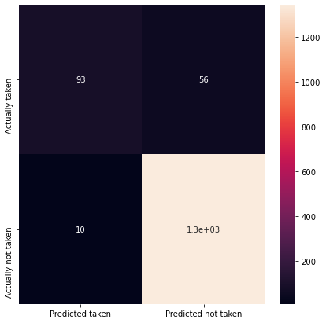

```python
df_cm = pd.DataFrame(cm, index = [i for i in ["Actually taken", "Actually not taken"]],
                    columns=[i for i in ["Predicted taken", "Predicted not taken"]])
plt.figure(figsize=(7,7))
sns.heatmap(df_cm, annot=True)
```

```python
tp = cm[0][0]
fn = cm[0][1]
fp = cm[1][0]
tn = cm[1][1]
total = tp+fn+fp+tn
```

```python
print("Results of prediction on test set:")
print("{} loans predicted by model and actually taken".format(tp))
print("{} loans predicted by model but actually not taken".format(fp))
print("{} loans not predicted by model but actually taken".format(fn))
print("{} loans not predicted by model and not actually taken".format(tn))
```

```
Results of prediction on test set:
93 loans predicted by model and actually taken
10 loans predicted by model but actually not taken
56 loans not predicted by model but actually taken
1341 loans not predicted by model and not actually taken
```

```python
accuracy    = (tp + tn) / total
precicion   = tp / (tp + fp)
recall      = tp / (tp + fn)
specificity = tn / (tn + fp)
f1_score    = 2 * (recall * precicion) / (recall + precicion)
```

```python
print ("Accuracy     = {}".format(accuracy))
print ("Precision    = {}".format(precicion))
print ("Recall       = {}".format(recall))
print ("Specificity  = {}".format(specificity))
print ("F1 score     = {}".format(f1_score))
```

```
Accuracy     = 0.956
Precision    = 0.9029126213592233
Recall       = 0.6241610738255033
Specificity  = 0.9925980754996299
F1 score     = 0.738095238095238
```

```python
r = metrics.roc_auc_score(y_test, y_predict)
print("ROC_AUC_SCORE = ", r)
```

```
ROC_AUC_SCORE =  0.8083795746625666
```

```python
# calculate the fpr and tpr for all thresholds of the classification
probs = model.predict_proba(x_test)
preds = probs[:,1]
fpr, tpr, threshold = metrics.roc_curve(y_test, preds)
roc_auc = metrics.auc(fpr, tpr)
```

```python
closest05 = (np.abs(threshold - 0.5)).argmin()
best_tpr_fpr = (tpr-fpr).argmax()
```

Plot ROC, mark the threshold point closest to 0.5 and the threshold with the best (true positive ratio - false positive ratio)

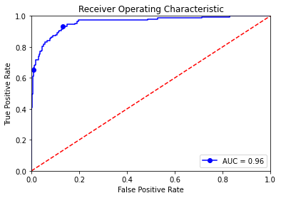

```python
# method I: plt
plt.title('Receiver Operating Characteristic')
plt.plot(fpr, tpr, 'b', label = 'AUC = %0.2f' % roc_auc, markevery=[closest05, best_tpr_fpr], marker="o")
plt.legend(loc = 'lower right')
plt.plot([0, 1], [0, 1],'r--')
plt.xlim([0, 1])
plt.ylim([0, 1])
plt.ylabel('True Positive Rate')
plt.xlabel('False Positive Rate')
plt.show()
```

## 5. Find out coefficients of all the attributes and show the output in a data frame with column names? For test data show all the rows where the predicted class is not equal to the observed class. (10 marks)

### Find out coefficients of all the attributes and show the output in a data frame with column names

```python
coeff_df = pd.DataFrame({'Parameter':X.columns, 'Coefficient':model.coef_[0]})
```

```python
coeff_df = coeff_df.append({'Parameter': 'Intercept', 'Coefficient': model.intercept_[0]}, ignore_index=True)
```

```python
coeff_df
```

|  | Parameter | Coefficient |
| --- | --- | --- |
| 0 | Age | 0.051913 |
| 1 | Income | 2.310794 |
| 2 | Family | 0.679795 |
| 3 | CCAvg | 0.316257 |
| 4 | Mortgage | 0.089138 |
| 5 | Securities Account | -0.851461 |
| 6 | CD Account | 3.089663 |
| 7 | Online | -0.605208 |
| 8 | CreditCard | -0.898822 |
| 9 | Education_2 | 2.951742 |
| 10 | Education_3 | 3.054376 |
| 11 | ZIP Code_90xxx | -0.150010 |
| 12 | ZIP Code_91xxx | -0.235489 |
| 13 | ZIP Code_92xxx | 0.070912 |
| 14 | ZIP Code_93xxx | 0.069585 |
| 15 | ZIP Code_95xxx | -0.149396 |
| 16 | ZIP Code_96xxx | -0.377605 |
| 17 | Intercept | -5.639700 |

For test data show all the rows where the predicted class is not equal to the observed class.

```python
mispredictions = np.not_equal(y_test.values.ravel(), y_predict)
```

```python
df = x_test
df.insert(0, 'Predicted', y_predict, True)
df.insert(0, 'Actual', y_test, True)
```

```python
pd.set_option('display.max_rows',100)
df[mispredictions]
```

|  | Actual | Predicted | Age | Income | Family | CCAvg | Mortgage | Securities Account | CD Account | Online | CreditCard | Education_2 | Education_3 | ZIP Code_90xxx | ZIP Code_91xxx | ZIP Code_92xxx | ZIP Code_93xxx | ZIP Code_95xxx | ZIP Code_96xxx |
| --- | --- | --- | --- | --- | --- | --- | --- | --- | --- | --- | --- | --- | --- | --- | --- | --- | --- | --- | --- |
| 932 | 0 | 1 | 0.493944 | 0.830470 | 0.525991 | -0.078935 | -0.555524 | 1 | 1 | 1 | 1 | 1 | 0 | 0 | 0 | 0 | 0 | 0 | 0 |
| 4377 | 1 | 0 | -1.076460 | 1.547407 | -1.216855 | 0.436091 | -0.555524 | 0 | 0 | 1 | 0 | 0 | 1 | 0 | 0 | 1 | 0 | 0 | 0 |
| 3988 | 1 | 0 | 1.191902 | 0.243885 | -1.216855 | 0.836667 | -0.555524 | 0 | 1 | 0 | 1 | 0 | 1 | 0 | 1 | 0 | 0 | 0 | 0 |
| 3271 | 1 | 0 | 0.581189 | 0.417688 | 1.397414 | 1.237243 | -0.555524 | 0 | 0 | 0 | 1 | 1 | 0 | 1 | 0 | 0 | 0 | 0 | 0 |
| 349 | 1 | 0 | -1.687172 | -0.299250 | -0.345432 | 0.607766 | 0.742365 | 0 | 0 | 0 | 0 | 0 | 0 | 0 | 0 | 0 | 1 | 0 | 0 |
| 927 | 1 | 0 | 1.715370 | 0.461138 | 0.525991 | 1.008342 | 0.801360 | 0 | 0 | 0 | 1 | 1 | 0 | 0 | 0 | 0 | 0 | 1 | 0 |
| 2968 | 1 | 0 | -0.116768 | 1.916739 | 1.397414 | -0.365061 | 2.404056 | 0 | 0 | 0 | 0 | 0 | 0 | 1 | 0 | 0 | 0 | 0 | 0 |
| 1626 | 0 | 1 | -1.250949 | 2.307795 | -0.345432 | 2.725096 | -0.555524 | 0 | 0 | 0 | 0 | 0 | 0 | 0 | 0 | 0 | 1 | 0 | 0 |
| 1518 | 1 | 0 | -0.204013 | -0.212348 | 1.397414 | 0.607766 | 1.617457 | 0 | 0 | 1 | 0 | 0 | 1 | 0 | 0 | 0 | 0 | 1 | 0 |
| 2478 | 0 | 1 | -1.338194 | 2.264345 | -0.345432 | 2.725096 | -0.555524 | 0 | 0 | 0 | 0 | 0 | 0 | 0 | 0 | 0 | 0 | 0 | 0 |
| 1277 | 0 | 1 | -0.029524 | 2.611951 | -0.345432 | 3.926823 | 3.652782 | 0 | 0 | 0 | 0 | 0 | 0 | 0 | 0 | 1 | 0 | 0 | 0 |
| 57 | 1 | 0 | 0.930168 | 1.243252 | -0.345432 | -0.422286 | -0.555524 | 0 | 0 | 0 | 0 | 0 | 1 | 0 | 0 | 0 | 0 | 1 | 0 |
| 4302 | 1 | 0 | 0.581189 | 0.243885 | 0.525991 | 0.836667 | -0.555524 | 0 | 0 | 0 | 0 | 0 | 1 | 0 | 0 | 1 | 0 | 0 | 0 |
| 891 | 1 | 0 | -1.163704 | 1.004273 | 1.397414 | 1.981169 | 2.404056 | 0 | 1 | 1 | 1 | 0 | 0 | 0 | 0 | 0 | 0 | 0 | 0 |
| 941 | 1 | 0 | -0.640236 | 1.199801 | 1.397414 | 1.408918 | 0.821025 | 0 | 0 | 0 | 0 | 0 | 0 | 0 | 0 | 1 | 0 | 0 | 0 |
| 1784 | 1 | 0 | 0.755678 | 0.982547 | 0.525991 | 0.035515 | -0.555524 | 1 | 1 | 0 | 0 | 0 | 0 | 0 | 1 | 0 | 0 | 0 | 0 |
| 1579 | 1 | 0 | -1.425438 | 1.047724 | 1.397414 | 0.607766 | -0.555524 | 0 | 0 | 0 | 1 | 0 | 0 | 0 | 0 | 0 | 0 | 0 | 0 |
| 1177 | 1 | 0 | -1.512683 | -0.060271 | -1.216855 | 0.779442 | 0.909517 | 1 | 1 | 1 | 0 | 1 | 0 | 1 | 0 | 0 | 0 | 0 | 0 |
| 4016 | 1 | 0 | 0.668434 | 2.155718 | 1.397414 | 0.436091 | 3.642950 | 0 | 0 | 1 | 0 | 0 | 0 | 0 | 1 | 0 | 0 | 0 | 0 |
| 3784 | 1 | 0 | -1.338194 | 0.895646 | 1.397414 | 1.065567 | -0.555524 | 0 | 0 | 1 | 0 | 1 | 0 | 0 | 0 | 0 | 0 | 0 | 0 |
| 322 | 1 | 0 | 1.540880 | 0.591491 | -1.216855 | 1.122792 | -0.555524 | 1 | 1 | 1 | 0 | 0 | 0 | 0 | 0 | 1 | 0 | 0 | 0 |
| 2158 | 1 | 0 | 0.406700 | 0.200434 | 1.397414 | 0.664991 | -0.555524 | 0 | 0 | 0 | 1 | 0 | 0 | 0 | 0 | 0 | 0 | 0 | 0 |
| 1768 | 1 | 0 | -0.204013 | 1.178076 | 1.397414 | 1.923944 | 0.270405 | 0 | 0 | 0 | 0 | 0 | 0 | 0 | 0 | 1 | 0 | 0 | 0 |
| 1577 | 1 | 0 | -0.989215 | -0.190623 | -1.216855 | 0.607766 | 1.676451 | 0 | 0 | 1 | 0 | 0 | 0 | 0 | 0 | 1 | 0 | 0 | 0 |
| 2024 | 1 | 0 | -0.814726 | 0.852195 | 1.397414 | -0.994537 | -0.555524 | 0 | 0 | 0 | 0 | 0 | 0 | 0 | 0 | 0 | 0 | 0 | 0 |
| 1499 | 1 | 0 | 0.581189 | 0.374237 | -1.216855 | 1.351693 | -0.555524 | 0 | 1 | 1 | 1 | 1 | 0 | 0 | 0 | 1 | 0 | 0 | 0 |
| 3573 | 1 | 0 | 1.279146 | 1.981915 | 0.525991 | 2.095620 | -0.555524 | 0 | 0 | 0 | 1 | 0 | 0 | 1 | 0 | 0 | 0 | 0 | 0 |
| 2544 | 1 | 0 | 1.104657 | 0.352512 | -1.216855 | 0.951117 | -0.555524 | 0 | 0 | 0 | 0 | 1 | 0 | 0 | 0 | 0 | 0 | 1 | 0 |
| 2268 | 1 | 0 | -1.599928 | 0.678392 | -1.216855 | 0.607766 | -0.555524 | 1 | 0 | 0 | 0 | 1 | 0 | 0 | 0 | 0 | 0 | 0 | 0 |
| 2533 | 1 | 0 | 0.755678 | 0.808744 | -1.216855 | -0.479511 | -0.555524 | 0 | 0 | 1 | 0 | 1 | 0 | 0 | 0 | 0 | 1 | 0 | 0 |
| 2262 | 1 | 0 | 0.842923 | 1.243252 | -0.345432 | -0.708412 | -0.555524 | 0 | 0 | 0 | 1 | 1 | 0 | 0 | 0 | 0 | 0 | 1 | 0 |
| 4532 | 1 | 0 | 0.232210 | 1.286703 | -0.345432 | 0.664991 | -0.555524 | 0 | 0 | 1 | 0 | 1 | 0 | 1 | 0 | 0 | 0 | 0 | 0 |
| 4575 | 1 | 0 | 0.668434 | 0.895646 | -0.345432 | -0.822862 | -0.555524 | 0 | 0 | 0 | 0 | 0 | 1 | 1 | 0 | 0 | 0 | 0 | 0 |
| 1432 | 0 | 1 | -1.687172 | 2.633676 | -1.216855 | 2.513363 | -0.555524 | 0 | 0 | 0 | 0 | 0 | 0 | 1 | 0 | 0 | 0 | 0 | 0 |
| 1328 | 1 | 0 | 1.279146 | 1.547407 | 1.397414 | 2.839546 | 3.180823 | 0 | 0 | 0 | 1 | 0 | 0 | 0 | 0 | 0 | 0 | 1 | 0 |
| 1559 | 1 | 0 | 1.191902 | 0.613216 | 1.397414 | 0.607766 | 0.575213 | 0 | 0 | 1 | 0 | 1 | 0 | 0 | 0 | 1 | 0 | 0 | 0 |
| 1913 | 1 | 0 | 1.017412 | 1.308428 | 1.397414 | -0.593961 | 1.391309 | 0 | 0 | 1 | 0 | 0 | 0 | 0 | 0 | 1 | 0 | 0 | 0 |
| 1126 | 1 | 0 | -1.163704 | 0.656667 | -0.345432 | 1.008342 | -0.555524 | 0 | 0 | 0 | 1 | 0 | 0 | 0 | 0 | 0 | 0 | 1 | 0 |
| 4168 | 1 | 0 | 1.279146 | 1.417055 | 1.397414 | -0.880087 | -0.555524 | 0 | 0 | 1 | 0 | 0 | 0 | 0 | 0 | 0 | 0 | 1 | 0 |
| 2539 | 1 | 0 | -1.163704 | 0.526315 | -1.216855 | 1.294468 | 1.125832 | 1 | 1 | 0 | 0 | 0 | 0 | 0 | 0 | 0 | 0 | 1 | 0 |
| 2934 | 0 | 1 | -0.727481 | 2.633676 | -0.345432 | 2.610646 | 5.688108 | 0 | 0 | 1 | 0 | 0 | 0 | 0 | 1 | 0 | 0 | 0 | 0 |
| 3758 | 0 | 1 | 0.144966 | 2.720577 | -0.345432 | 2.707928 | -0.555524 | 0 | 0 | 1 | 0 | 0 | 0 | 0 | 0 | 0 | 0 | 0 | 0 |
| 3835 | 1 | 0 | -1.076460 | 1.243252 | 0.525991 | 0.149965 | -0.555524 | 1 | 0 | 0 | 0 | 0 | 1 | 1 | 0 | 0 | 0 | 0 | 0 |
| 3312 | 0 | 1 | 0.144966 | 2.525049 | -0.345432 | 3.926823 | -0.555524 | 0 | 0 | 0 | 0 | 0 | 0 | 0 | 0 | 0 | 0 | 0 | 0 |
| 3039 | 1 | 0 | -0.989215 | 1.460506 | -0.345432 | 1.695044 | -0.555524 | 0 | 0 | 0 | 1 | 0 | 1 | 0 | 0 | 0 | 0 | 1 | 0 |
| 1225 | 1 | 0 | -1.338194 | 0.960822 | -0.345432 | 0.493316 | -0.555524 | 0 | 0 | 0 | 0 | 1 | 0 | 0 | 0 | 0 | 0 | 0 | 0 |
| 2874 | 1 | 0 | 0.319455 | 0.873921 | -1.216855 | 0.321641 | -0.555524 | 0 | 0 | 1 | 0 | 0 | 1 | 0 | 1 | 0 | 0 | 0 | 0 |
| 4156 | 0 | 1 | -0.727481 | 2.590225 | -1.216855 | 3.812373 | -0.555524 | 0 | 0 | 0 | 0 | 0 | 0 | 0 | 0 | 1 | 0 | 0 | 0 |
| 4702 | 1 | 0 | -0.901970 | 0.743568 | -0.345432 | 0.464703 | -0.555524 | 1 | 0 | 0 | 0 | 0 | 1 | 1 | 0 | 0 | 0 | 0 | 0 |
| 3343 | 1 | 0 | 1.453636 | 1.112900 | -1.216855 | -0.536736 | -0.555524 | 0 | 0 | 1 | 0 | 0 | 1 | 0 | 0 | 0 | 0 | 0 | 0 |
| 3318 | 1 | 0 | 0.057721 | 0.678392 | 1.397414 | 0.722217 | -0.555524 | 0 | 0 | 0 | 0 | 0 | 0 | 1 | 0 | 0 | 0 | 0 | 0 |
| 650 | 1 | 0 | 0.144966 | 1.047724 | -1.216855 | 1.809494 | 1.047172 | 1 | 0 | 0 | 0 | 0 | 1 | 1 | 0 | 0 | 0 | 0 | 0 |
| 2403 | 1 | 0 | -0.640236 | 1.438780 | 1.397414 | -0.822862 | -0.555524 | 0 | 0 | 0 | 0 | 0 | 0 | 1 | 0 | 0 | 0 | 0 | 0 |
| 1794 | 1 | 0 | 0.930168 | 0.526315 | 0.525991 | 1.122792 | -0.555524 | 0 | 0 | 0 | 0 | 0 | 1 | 0 | 1 | 0 | 0 | 0 | 0 |
| 1195 | 1 | 0 | -1.163704 | 1.069449 | -0.345432 | 0.550541 | -0.555524 | 0 | 0 | 1 | 0 | 1 | 0 | 0 | 0 | 1 | 0 | 0 | 0 |
| 785 | 0 | 1 | 0.057721 | 1.960189 | -0.345432 | 3.240122 | -0.555524 | 0 | 1 | 1 | 1 | 0 | 0 | 0 | 0 | 0 | 0 | 0 | 0 |
| 2159 | 1 | 0 | 1.366391 | 0.548040 | -1.216855 | 1.637819 | 1.951761 | 0 | 0 | 0 | 1 | 0 | 1 | 0 | 0 | 0 | 0 | 0 | 0 |
| 4418 | 1 | 0 | 1.191902 | 1.547407 | 1.397414 | -0.078935 | 1.391309 | 0 | 0 | 1 | 0 | 0 | 0 | 0 | 0 | 0 | 0 | 1 | 0 |
| 2136 | 1 | 0 | 0.406700 | 0.895646 | -1.216855 | -0.422286 | -0.555524 | 0 | 0 | 0 | 1 | 0 | 1 | 0 | 0 | 0 | 0 | 1 | 0 |
| 2536 | 1 | 0 | 0.493944 | 0.656667 | -1.216855 | 1.294468 | -0.555524 | 0 | 0 | 1 | 0 | 1 | 0 | 0 | 0 | 0 | 0 | 0 | 0 |
| 464 | 1 | 0 | -0.204013 | 0.200434 | 1.397414 | 0.951117 | -0.555524 | 0 | 0 | 0 | 1 | 0 | 1 | 0 | 0 | 0 | 0 | 0 | 0 |
| 1143 | 1 | 0 | -1.076460 | 1.004273 | -1.216855 | 0.722217 | -0.555524 | 0 | 0 | 1 | 0 | 0 | 1 | 0 | 0 | 0 | 0 | 0 | 0 |
| 1793 | 1 | 0 | -0.901970 | 0.852195 | 0.525991 | -0.651186 | -0.555524 | 0 | 0 | 1 | 0 | 0 | 1 | 0 | 0 | 0 | 0 | 0 | 0 |
| 813 | 1 | 0 | 0.406700 | 1.221527 | -1.216855 | -0.479511 | -0.555524 | 0 | 0 | 1 | 0 | 1 | 0 | 0 | 0 | 0 | 0 | 0 | 0 |
| 3766 | 1 | 0 | 1.191902 | 0.743568 | 1.397414 | 1.065567 | 2.433553 | 0 | 0 | 1 | 0 | 1 | 0 | 1 | 0 | 0 | 0 | 0 | 0 |
| 3651 | 1 | 0 | 0.319455 | 1.438780 | -1.216855 | -0.021710 | -0.555524 | 0 | 0 | 0 | 1 | 0 | 1 | 1 | 0 | 0 | 0 | 0 | 0 |